# HW4 PCA

## **4.1 Cereals Data**

Use the data for the breakfast cereals example in Section 4.8 to explore and summarize the data as follows:

### **a. Which variables are quantitative/numerical? Which are ordinal? Which are nominal?**

```r
cereals.df <- read.csv("Cereals.csv")
View(cereals.df)
summary(cereals.df)
```

```
     name               mfr                type              calories        protein
 Length:77          Length:77          Length:77          Min.   : 50.0   Min.   :1.000
 Class :character   Class :character   Class :character   1st Qu.:100.0   1st Qu.:2.000
 Mode  :character   Mode  :character   Mode  :character   Median :110.0   Median :3.000
                                                          Mean   :106.9   Mean   :2.545
                                                          3rd Qu.:110.0   3rd Qu.:3.000
                                                          Max.   :160.0   Max.   :6.000

      fat            sodium          fiber            carbo          sugars
 Min.   :0.000   Min.   :  0.0   Min.   : 0.000   Min.   : 5.0   Min.   : 0.000
 1st Qu.:0.000   1st Qu.:130.0   1st Qu.: 1.000   1st Qu.:12.0   1st Qu.: 3.000
 Median :1.000   Median :180.0   Median : 2.000   Median :14.5   Median : 7.000
 Mean   :1.013   Mean   :159.7   Mean   : 2.152   Mean   :14.8   Mean   : 7.026
 3rd Qu.:2.000   3rd Qu.:210.0   3rd Qu.: 3.000   3rd Qu.:17.0   3rd Qu.:11.000
 Max.   :5.000   Max.   :320.0   Max.   :14.000   Max.   :23.0   Max.   :15.000
                                                  NA's   :1      NA's   :1
     potass          vitamins          shelf           weight          cups
 Min.   : 15.00   Min.   :  0.00   Min.   :1.000   Min.   :0.50   Min.   :0.250
 1st Qu.: 42.50   1st Qu.: 25.00   1st Qu.:1.000   1st Qu.:1.00   1st Qu.:0.670
 Median : 90.00   Median : 25.00   Median :2.000   Median :1.00   Median :0.750
 Mean   : 98.67   Mean   : 28.25   Mean   :2.208   Mean   :1.03   Mean   :0.821
 3rd Qu.:120.00   3rd Qu.: 25.00   3rd Qu.:3.000   3rd Qu.:1.00   3rd Qu.:1.000
 Max.   :330.00   Max.   :100.00   Max.   :3.000   Max.   :1.50   Max.   :1.500
 NA's   :2
     rating
 Min.   :18.04
 1st Qu.:33.17
 Median :40.40
 Mean   :42.67
 3rd Qu.:50.83
 Max.   :93.70
```

From the summary we know that there are 15 variables in total (excluding names), and they can be separated into three types:

1. numerical (12): calories, protein, fat, sodium, fiber, carbo, sugars, potass, vitamins, weight, cups, rating
2. ordinal (1): shelf
3. nominal (2): mfr, type

Note: Most data falls into these types naturally, while some columns like “vitamins”, “shelf” and “type” are kind of ambiguous. For example, “vitamins” are discrete numbers in 0, 25, and 100, so it should be numerical, but it may actually serves as the ordinal data, since it clearly show the relative relationship of the cereals. Another example is that, “shelf” is ordered so should be ordinal, but it is also numerical in our case, and it can also be nominal, as the order here is just where the cereals are placed, while it does not reveal the relationship between them. Also, “type” column has two classes (cold/hot), so it could be nominal, but if we consider “type” as a measurement of temperature (high/low), then it could be ordinal.

### **b. Compute the mean, median, min, max, and standard deviation for each of the quantitative variables.**

```r
cereals.quant <- na.omit(cereals.df[, -1:-3])
data.frame(mean=sapply(cereals.quant, mean),
           median=sapply(cereals.quant, median),
           min=sapply(cereals.quant, min),
           max=sapply(cereals.quant, max),
           sd=sapply(cereals.quant, sd))
```

|  | mean | median | min | max | sd |
| --- | --- | --- | --- | --- | --- |
| calories | 107.0270270 | 110.00000 | 50.00000 | 160.00000 | 19.8438928 |
| protein | 2.5135135 | 2.50000 | 1.00000 | 6.00000 | 1.0758016 |
| fat | 1.0000000 | 1.00000 | 0.00000 | 5.00000 | 1.0068260 |
| sodium | 162.3648649 | 180.00000 | 0.00000 | 320.00000 | 82.7697871 |
| fiber | 2.1756757 | 2.00000 | 0.00000 | 14.00000 | 2.4233912 |
| carbo | 14.7297297 | 14.50000 | 5.00000 | 23.00000 | 3.8916746 |
| sugars | 7.1081081 | 7.00000 | 0.00000 | 15.00000 | 4.3591113 |
| potass | 98.5135135 | 90.00000 | 15.00000 | 330.00000 | 70.8786815 |
| vitamins | 29.0540541 | 25.00000 | 0.00000 | 100.00000 | 22.2943521 |
| shelf | 2.2162162 | 2.00000 | 1.00000 | 3.00000 | 0.8320674 |

[output cut: 3 more lines]

### **c. Use R to plot a histogram for each of the quantitative variables. Based on the histograms and summary statistics, answer the following questions:**

1. Which variables have the largest variability?
2. Which variables seem skewed?
3. Are there any values that seem extreme?

```
[1] "calories: 393.780081451314"
[1] "protein: 1.15734912995187"
[1] "fat: 1.01369863013699"
[1] "sodium: 6850.83765272121"
[1] "fiber: 5.87282487967419"
[1] "carbo: 15.1451314328027"
[1] "sugars: 19.0018511662347"
[1] "potass: 5023.78748611625"
[1] "vitamins: 497.038134024435"
[1] "shelf: 0.692336171788227"
[1] "weight: 0.0235363198815254"
[1] "cups: 0.0555617178822658"
[1] "rating: 196.94508612474"
```

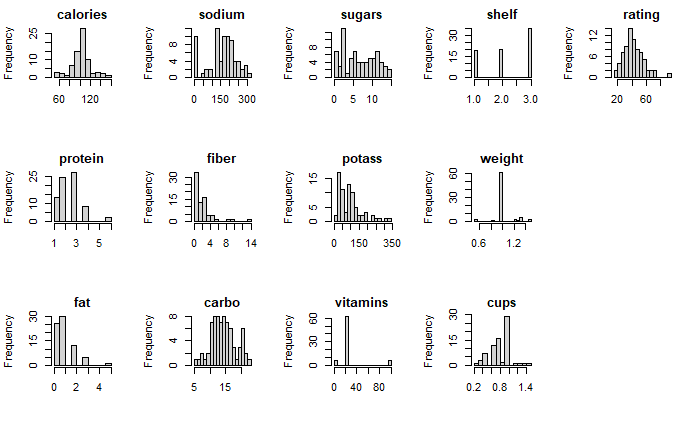

```r
par(mfcol=c(3, 5))
for (i in 1:ncol(cereals.quant)) {
  data <- cereals.quant[, i]
  name <- names(cereals.quant[i])
  hist(data, main=name, xlab='', breaks=15)
  print(paste0(name, ': ', var(data)))
}
```

1. From var() we know that sodium (~7k) and potass (~5k) has the largest variability. Note: the data are not normalized so far, so the variability relies on the absolute size of the data (larger range yields larger variability). However, using the PCA, we should work on normalized data, then we will care about the relative variability instead of absolute variability.
2. From the histograms we know that the distribution of these data varies a lot. If we only consider the case where the distribution in continuous but skewed, then “fat”, “fiber”, “potass”, “fat” will falls into the category. As for other variables, “calories” is almost centralized, “sugars” is flatten so it has a very large (relative) variance, “shelf” and “vitamins” belongs to discrete distribution.
3. There are not many extreme values (outliers) in the data. There is a small amount of samples in “rating” that deviate from the distribution a little bit, and a small portion in “cups” that is flat at the tail, but these “outliers” are not too far away from the center to cause the failure of the models.

### **d. Use R to plot a side-by-side boxplot comparing the calories in hot vs. cold cereals. What does this plot show us?**

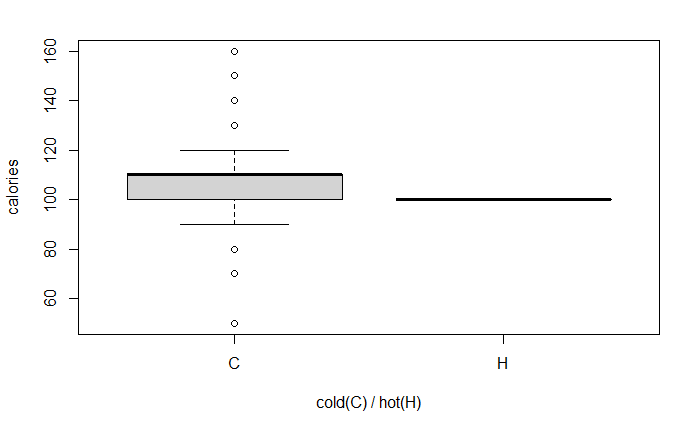

```r
boxplot(cereals.df$calories ~ cereals.df$type, xlab="cold(C) / hot(H)", ylab="calories")
```

This plot shows that for type “cold”, the calories is centered at ~110, and most data falls into the range from ~90 to ~125, while for type “hot”, the calories is always centered at 100. This does not necessarily proves that hot cereals always has a calories of 100 with almost zero variation, because the data we use here only has 3 records of type “hot” out of 77 records in total, and they all happen to have calories of 100. If the data contains more cereals of type “hot”, then we will have a more reasonable and conclusive boxplot for it.

### **e. Use R to plot a side-by-side boxplot of consumer rating as a function of the shelf height. If we were to predict consumer rating from shelf height, does it appear that we need to keep all three categories of shelf height?**

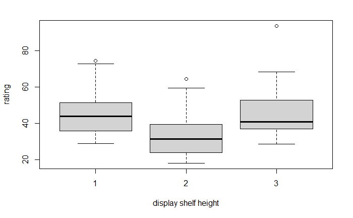

```r
boxplot(cereals.df$rating ~ cereals.df$shelf, xlab="display shelf height", ylab="rating")
```

From this boxplot we know that shelf “1” and “3” have a similar distribution for rating, as they both centered at ~45 and range from ~35 to ~55, while for shelf “2”, the distribution is shifted downward with a center of ~35 and range from ~15 to ~40. If we want to do a simply prediction that use only the shelf height to predict consumer ratings, then we can draw the conclusion directly from the distribution shown above without any classification models, that is, the cereals on shelf “2” tends to have a lower rating, and shelf “1” and “3” have higher and very similar rating distribution. This may be useful and sufficient for the shop to rearrange the cereals, so in this case, there is not need to keep all three categories. However, if we do want to use a classification model for it, then we certainly needs all three of them, as their distribution still varies and have different statistical features. Also, for the histogram shown in section (c), we know that the data spread out to these three categories almost “evenly”, unlike the “hot”/“cold” data where one side is extremly more than the other, so in this case, we should not drop any category.

### **f. Compute the correlation table for the quantitative variable (function cor()). In addition, generate a matrix plot for these variables (function plot(data)).**

1. Which pair of variables is most strongly correlated?
2. How can we reduce the number of variables based on these correlations?
3. How would the correlations change if we normalized the data first?

```r
cereals.cor <- round(cor(cereals.quant), 2)
cereals.cor
```

```
         calories protein   fat sodium fiber carbo sugars potass vitamins shelf weight  cups
calories     1.00    0.03  0.51   0.30 -0.30  0.27   0.57  -0.07     0.26  0.09   0.70  0.09
protein      0.03    1.00  0.20   0.01  0.51 -0.04  -0.29   0.58     0.05  0.20   0.23 -0.24
fat          0.51    0.20  1.00   0.00  0.01 -0.28   0.29   0.20    -0.03  0.28   0.22 -0.16
sodium       0.30    0.01  0.00   1.00 -0.07  0.33   0.04  -0.04     0.33 -0.12   0.31  0.12
fiber       -0.30    0.51  0.01  -0.07  1.00 -0.38  -0.15   0.91    -0.04  0.31   0.25 -0.51
carbo        0.27   -0.04 -0.28   0.33 -0.38  1.00  -0.45  -0.37     0.25 -0.19   0.14  0.36
sugars       0.57   -0.29  0.29   0.04 -0.15 -0.45   1.00   0.00     0.07  0.06   0.46 -0.03
potass      -0.07    0.58  0.20  -0.04  0.91 -0.37   0.00   1.00     0.00  0.39   0.42 -0.50
vitamins     0.26    0.05 -0.03   0.33 -0.04  0.25   0.07   0.00     1.00  0.28   0.32  0.13
shelf        0.09    0.20  0.28  -0.12  0.31 -0.19   0.06   0.39     0.28  1.00   0.19 -0.35
weight       0.70    0.23  0.22   0.31  0.25  0.14   0.46   0.42     0.32  0.19   1.00 -0.20
cups         0.09   -0.24 -0.16   0.12 -0.51  0.36  -0.03  -0.50     0.13 -0.35  -0.20  1.00
rating      -0.69    0.47 -0.41  -0.38  0.60  0.06  -0.76   0.42    -0.21  0.05  -0.30 -0.22
         rating
calories  -0.69
protein    0.47
fat       -0.41
sodium    -0.38
fiber      0.60
carbo      0.06
sugars    -0.76
potass     0.42
vitamins  -0.21
shelf      0.05
weight    -0.30
cups      -0.22
rating     1.00
```

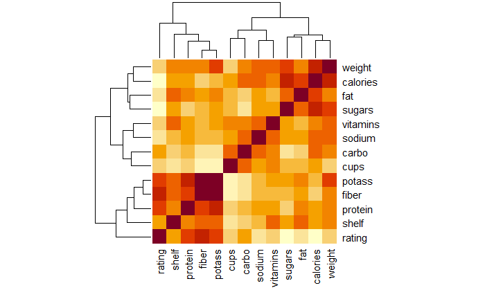

```r
heatmap(cereals.cor, scale="none")
```

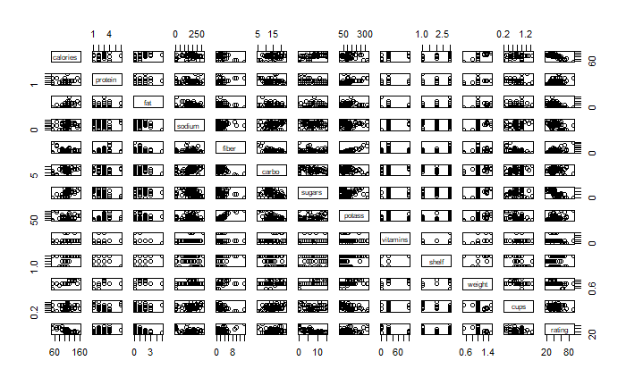

```r
plot(cereals.quant)
```

1. From the matrix plot and correlation table we know there are at least three pairs of variable that are strongly correlated:
   1. “fiber”-“potass”: 0.9, positive correlations
   2. “sugars”-“rating”: -0.76, negative correlations
   3. “calories”-“rating”: -0.69, negative correlations
2. Once we have the strongly correlated variables, we can either use one of them or combine them together into a new single variable that represents the change in two variables at the same time. This process will reduce the number of variables without losing much information.
3. The normalization will not change the correlation, as the correlation measures the relative relationship between two variables, while scale/rescale any one or two of them will not affect it. As for the matrix plot for correlations, normalization will simply shift x or y axis, and expand or shrink them, which may change the slope, but not the trend of correlated or not correlated.

## **4.2 University Rankings Data**

The dataset on American college and university rankings (available from www.dataminingbook.com) contains information on 1302 American colleges and universities offering an undergraduate program. For each university, there are 17 measurements that include continuous measurements (such as tuition and graduation rate) and categorical measurements (such as location by state and whether it is a private or a public school).

### **a. Remove all categorical variables. Then remove all records with missing numerical measurements from the dataset.**

```r
university.df <- read.csv("Universities.csv")
View(university.df)
summary(university.df)
```

```
 College.Name          State           Public..1...Private..2. X..appli..rec.d
 Length:1302        Length:1302        Min.   :1.000           Min.   :   35.0
 Class :character   Class :character   1st Qu.:1.000           1st Qu.:  695.8
 Mode  :character   Mode  :character   Median :2.000           Median : 1470.0
                                       Mean   :1.639           Mean   : 2752.1
                                       3rd Qu.:2.000           3rd Qu.: 3314.2
                                       Max.   :2.000           Max.   :48094.0
                                                               NA's   :10
 X..appl..accepted X..new.stud..enrolled X..new.stud..from.top.10. X..new.stud..from.top.25.
 Min.   :   35.0   Min.   :  18.0        Min.   : 1.00             Min.   :  6.00
 1st Qu.:  554.5   1st Qu.: 236.0        1st Qu.:13.00             1st Qu.: 36.75
 Median : 1095.0   Median : 447.0        Median :21.00             Median : 50.00
 Mean   : 1870.7   Mean   : 778.9        Mean   :25.67             Mean   : 52.35
 3rd Qu.: 2303.0   3rd Qu.: 984.0        3rd Qu.:32.00             3rd Qu.: 66.00
 Max.   :26330.0   Max.   :7425.0        Max.   :98.00             Max.   :100.00
 NA's   :11        NA's   :5             NA's   :235               NA's   :202
 X..FT.undergrad X..PT.undergrad   in.state.tuition out.of.state.tuition      room
 Min.   :   59   Min.   :    1.0   Min.   :  480    Min.   : 1044        Min.   : 500
 1st Qu.:  966   1st Qu.:  131.2   1st Qu.: 2580    1st Qu.: 6111        1st Qu.:1710
 Median : 1812   Median :  472.0   Median : 8050    Median : 8670        Median :2200
 Mean   : 3693   Mean   : 1081.5   Mean   : 7897    Mean   : 9277        Mean   :2515
 3rd Qu.: 4540   3rd Qu.: 1313.0   3rd Qu.:11600    3rd Qu.:11659        3rd Qu.:3040
 Max.   :31643   Max.   :21836.0   Max.   :25750    Max.   :25750        Max.   :7400
 NA's   :3       NA's   :32        NA's   :30       NA's   :20           NA's   :321
     board        add..fees      estim..book.costs estim..personal.. X..fac..w.PHD
 Min.   : 531   Min.   :   9.0   Min.   :  90      Min.   :  75      Min.   :  8.00
 1st Qu.:1619   1st Qu.: 130.0   1st Qu.: 480      1st Qu.: 900      1st Qu.: 57.00
 Median :1980   Median : 264.5   Median : 502      Median :1250      Median : 71.00
 Mean   :2061   Mean   : 392.0   Mean   : 550      Mean   :1389      Mean   : 68.65
 3rd Qu.:2402   3rd Qu.: 480.0   3rd Qu.: 600      3rd Qu.:1794      3rd Qu.: 82.00
 Max.   :6250   Max.   :4374.0   Max.   :2340      Max.   :6900      Max.   :105.00
 NA's   :498    NA's   :274      NA's   :48        NA's   :181       NA's   :32
 stud..fac..ratio Graduation.rate
 Min.   : 2.30    Min.   :  8.00
 1st Qu.:11.80    1st Qu.: 47.00
 Median :14.30    Median : 60.00
 Mean   :14.86    Mean   : 60.41
 3rd Qu.:17.60    3rd Qu.: 74.00
 Max.   :91.80    Max.   :118.00
 NA's   :2        NA's   :98
```

```r
university.quant <- university.df[, -1:-3] # remove "Name", "State", "Public/Private"
university.quant <- na.omit(university.quant) # remove NA's
print(paste0("Original dim: ", toString(dim(university.df)),
             " After cleaning: ", toString(dim(university.quant))))
```

```
[1] "Original dim: 1302, 20 After cleaning: 471, 17"
```

### **b. Conduct a principal components analysis on the cleaned data and comment on the results. Should the data be normalized? Discuss what characterizes the components you consider key.**

```r
university.pcs <- prcomp(university.quant, scale.=TRUE)
summary(university.pcs)
```

```
Importance of components:
                          PC1    PC2     PC3     PC4     PC5     PC6     PC7     PC8     PC9
Standard deviation     2.2749 2.1426 1.09838 1.03247 0.97599 0.87284 0.80327 0.77279 0.70316
Proportion of Variance 0.3044 0.2700 0.07097 0.06271 0.05603 0.04481 0.03796 0.03513 0.02908
Cumulative Proportion  0.3044 0.5745 0.64542 0.70813 0.76416 0.80898 0.84693 0.88206 0.91115
                         PC10    PC11    PC12   PC13    PC14    PC15    PC16    PC17
Standard deviation     0.6622 0.62788 0.54973 0.4383 0.30389 0.20002 0.17428 0.14388
Proportion of Variance 0.0258 0.02319 0.01778 0.0113 0.00543 0.00235 0.00179 0.00122
Cumulative Proportion  0.9369 0.96013 0.97791 0.9892 0.99464 0.99700 0.99878 1.00000
```

The result above shows the new PCs constructed from all 17 numerical variables. From the result we know that if we want to keep 95% of deviation, we need 11 PCs, which indicated the old data contains about 6 variables that are strongly correlated with others. With 1/3 of dimension reduced, we can perform classification/regression models for further investigation.

The data should be normalized, because the PCA algorithm finds the direction where the deviation is maximized, while in the original data, some columns are significantly larger than the others (“room” ~3000 compared to “Graduation.rate” ~60), which becomes predominant to the algorithm. In that case, the columns with small values will simply be neglected, which causes the lost of information. The key PCs should have the characterization that they generalized the features of data without losing much information. In the ideal case, they will have a similar proportion of variance, but also perpendicular to each other (ensured by the algorithm) so they keep the features where the data expand the most, which could be crucial to separate the data points or perform other models.